# Finance project

```r
setwd("~/Library/CloudStorage/GoogleDrive-daniel.wiinberg@gmail.com/My Drive/DTU/02402 Introduction to Statistics/Project 1")
D <- read.table("finans1_data.csv", header=TRUE, sep=";", as.is=TRUE)
D <- D[ ,c("t","AGG","VAW","IWN","SPY")]
```

# Descriptive analysis

The raw data includes weekly returns for 95 ETFs, with the first week being 2006-5-5 and the last week being 2015-5-8 (date format is yyyy-mm-dd). In total this is 454 data points for every ETF.

From this raw data we select ETFs, they are:

- AGG - iShares Core Total US Bond Market ETF
- VAW - Vanguard Materials ETF
- IWN - iShares Russell 2000 Value Index Fund
- SPY - SPDR Trust, Series 1 (the Trust) is a unit investment trust

```r
## The first rows/observations
head(D)
```

|  | t | AGG | VAW | IWN | SPY |
| --- | --- | --- | --- | --- | --- |
| 1 | 2006-5-5 | -0.006088280 | 0.03157274 | 0.023603147 | 0.007986613 |
| 2 | 2006-5-12 | -0.003675345 | -0.02745995 | -0.048071912 | -0.024750981 |
| 3 | 2006-5-19 | 0.006660518 | -0.05000000 | -0.014096072 | -0.016558341 |
| 4 | 2006-5-26 | 0.001832248 | 0.01253870 | 0.009716824 | 0.010070810 |
| 5 | 2006-6-5 | -0.004775452 | -0.02232075 | -0.017734396 | -0.009814613 |
| 6 | 2006-6-12 | 0.001225115 | -0.06098514 | -0.038348495 | -0.024622404 |

From the rows we can se that we are dealing with quantitative data (the return of the ETF) and the week this return was given.

Looking through the data is can be seen that the data is mostly complete, assuming that the data point being 0 is correct. It can also be seen that SPY has an outlier of -18, which looks to be wrong in comparison to the rest of the data.

# Histogram

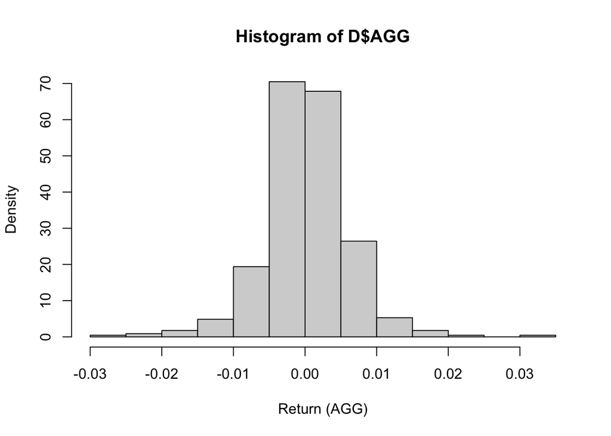

```r
## Histogram describing the empirical density of the weekly returns from
## AGG (histogram of weekly returns normalized to have an area of 1)
hist(D$AGG, xlab="Return (AGG)", prob=TRUE)
```

```r
?hist
```